# Cpastone_Milestone_Report

Sujitha P

January 10, 2019

# Peer-graded Assignment: Milestone Report

## Project Summary

The goal of this project is just to display that you’ve gotten used to working with the data and that you are on track to create your prediction algorithm.

Submit the findings of the milestone report on “rPubs”

The pourpose of the project:

This report provides a brief overview of the exploratory analysis performed on the text data which will be used on the Capstone project.

## Data loading and analysis

```r
library(tm)
library(wordcloud)
library(RColorBrewer)
library(dplyr)
library(ggplot2)
library(stringi)
```

```r
list.of.packages <- c("stringi", "tm", "wordcloud", "RColorBrewer")
new.packages <- list.of.packages[!(list.of.packages %in% installed.packages()[,"Package"])]
if(length(new.packages)) install.packages(new.packages, repos="http://cran.rstudio.com/")
```

```r
fileUrl <-"https://d396qusza40orc.cloudfront.net/dsscapstone/dataset/Coursera-SwiftKey.zip"
if (!file.exists("Coursera-SwiftKey.zip")){
  download.file(fileUrl, destfile = "Coursera-SwiftKey.zip")
}
unzip("Coursera-SwiftKey.zip")
```

```r
file.list = c("final/en_US/en_US.blogs.txt", "final/en_US/en_US.news.txt", "final/en_US/en_US.twitter.txt")
text <- list(blogs = "", news = "", twitter = "")
data.summary <- matrix(0, nrow = 3, ncol = 3, dimnames = list(c("blogs", "news", "twitter"),c("file size, Mb", "lines", "words")))
for (i in 1:3) {
  con <- file(file.list[i], "rb")
  text[[i]] <- readLines(con, encoding = "UTF-8",skipNul = TRUE)
  close(con)
  data.summary[i,1] <- round(file.info(file.list[i])$size / 1024^2, 2)
  data.summary[i,2] <- length(text[[i]])
  data.summary[i,3] <- sum(stri_count_words(text[[i]]))
}
```

```r
set.seed(123)
blogsSample <- sample(text$blogs, 0.01*length(text$blogs))
newsSample <- sample(text$news, 0.01*length(text$news))
twitterSample <- sample(text$twitter, 0.01*length(text$twitter))
dataSample <- c(blogsSample, newsSample, twitterSample)
sum <- sum(stri_count_words(dataSample))
```

```r
dataSample <- iconv(dataSample, 'UTF-8', 'ASCII')
corpus <- Corpus(VectorSource(as.data.frame(dataSample, stringsAsFactors = FALSE)))
corpus <- corpus %>%
  tm_map(tolower) %>%
  tm_map(PlainTextDocument) %>%
  tm_map(removePunctuation) %>%
  tm_map(removeNumbers) %>%
  tm_map(stripWhitespace)
term.doc.matrix <- TermDocumentMatrix(corpus)
term.doc.matrix <- as.matrix(term.doc.matrix)
word.freqs <- sort(rowSums(term.doc.matrix), decreasing=TRUE)
dm <- data.frame(word=names(word.freqs), freq=word.freqs)
```

# Exploratory Analysis

> Analysis of the dataset:

### Unigram Word Frequency:

> The Unigram chart below presents the most common 25 Unigrams

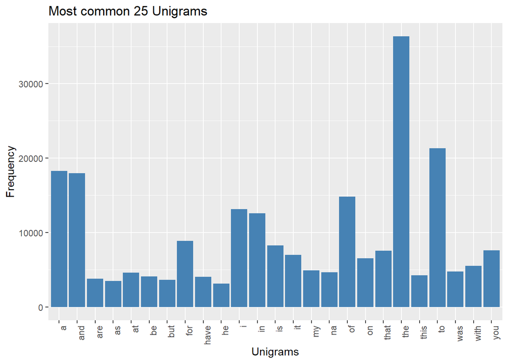

```r
unigram.df <- data.frame(table(unigram))
unigram.df <- unigram.df[order(unigram.df$Freq, decreasing = TRUE),]
ggplot(unigram.df[1:25,], aes(x=unigram, y=Freq)) +
  geom_bar(stat="Identity", fill="steelblue")+
  xlab("Unigrams") + ylab("Frequency")+
  ggtitle("Most common 25 Unigrams") +
  theme(axis.text.x=element_text(angle=90, hjust=1))
```

### BiGram Word Frequency:

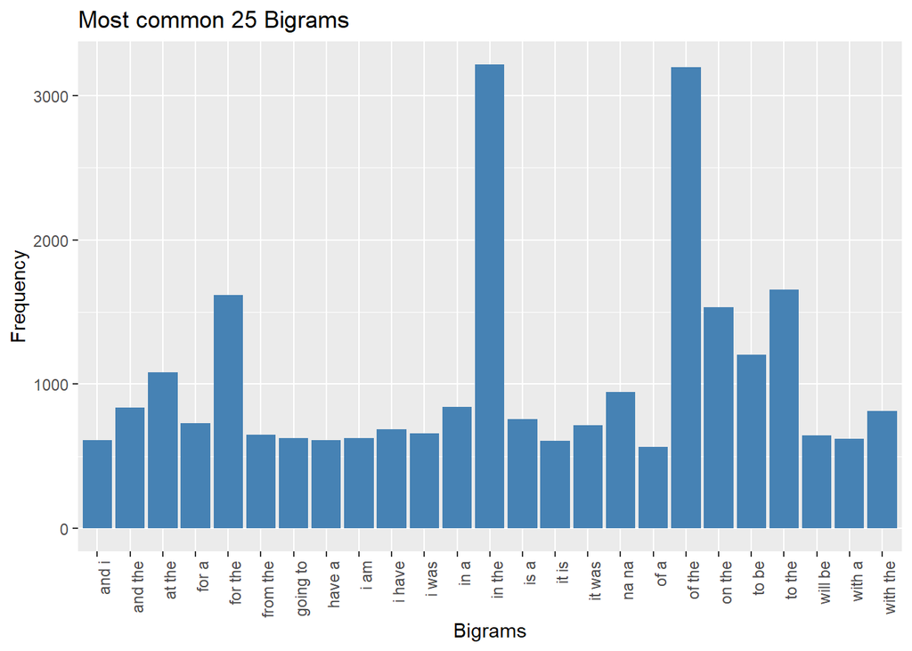

```r
bigram.df <- data.frame(table(bigram))
bigram.df <- bigram.df[order(bigram.df$Freq, decreasing = TRUE),]
ggplot(bigram.df[1:25,], aes(x=bigram, y=Freq)) +
  geom_bar(stat="Identity", fill="steelblue")+
  xlab("Bigrams") + ylab("Frequency")+
  ggtitle("Most common 25 Bigrams") +
  theme(axis.text.x=element_text(angle=90, hjust=1))
```

### Trigram Word Frequency:

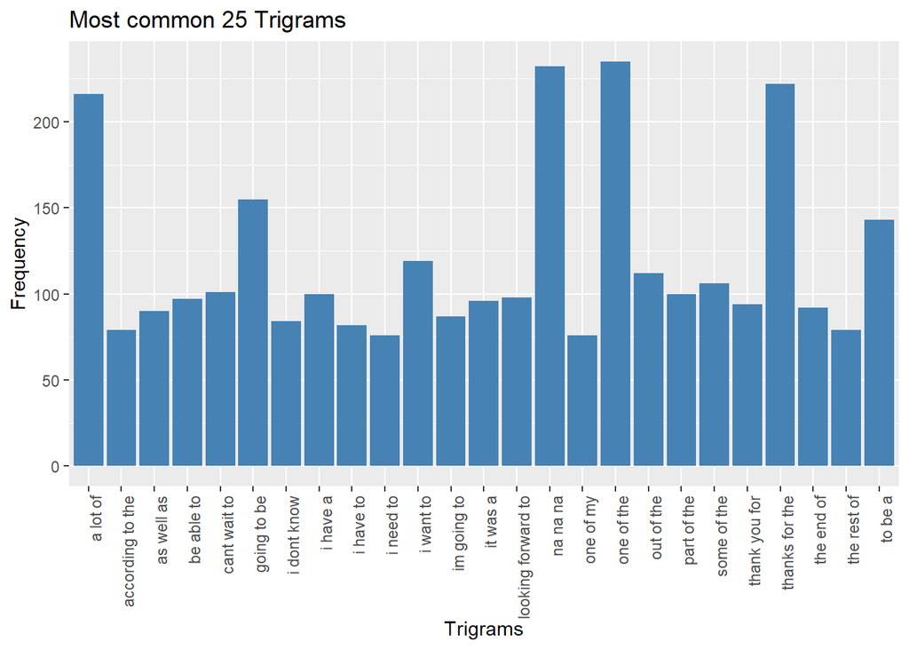

```r
trigram.df <- data.frame(table(trigram))
trigram.df <- trigram.df[order(trigram.df$Freq, decreasing = TRUE),]
ggplot(trigram.df[1:25,], aes(x=trigram, y=Freq)) +
  geom_bar(stat="Identity", fill="steelblue")+
  xlab("Trigrams") + ylab("Frequency")+
  ggtitle("Most common 25 Trigrams") +
  theme(axis.text.x=element_text(angle=90, hjust=1))
```

## Next Steps

For example, the probability of an untyped word can be estimated from the frequencies in the corpus of the n-grams containing that word in the last position conditioned on the presence the last typed word(s) as the first n - 1 words in the n-gram. One can use a weighted sum of frequencies, with the weights calculated using machine learning.

- Create a prediction alogrithm using on 4-gram
- Update the Data Cleaning process by remove punctation, non-alphabet characters (e.g. numbers), website addresses, white spaces, profanity and stopwords.
- Tune the prediction model for efficiency and accuracy.
- Build a Shiny App: giving one or more words, the prediction app will be suggest a list of possibles “next word” using the prediction algorithm.